# Principal component method

Valery Andruynichev

25 dec 2018 year

# Comparison of the effectiveness of the method of principal components for the portfolio of the currency pairs and a separate currency pairs.

## Specify the working directory.

```r
dir <- 'D:/GH/Currency'
setwd(dir)
```

### And connect the pakeges.

```r
library(ggplot2) # Plots
library(dplyr) # data manipulation
library(ggfortify) # Correct data
library(readr) # load data
library(xts) # work with .xts
library(formattable) # Correct data
library(tseries) # Statistical test
```

### Load necessary data.

```r
# USD/RUB data
U_R <- read_delim("USDRUB_TOM.csv",";", escape_double = FALSE, col_types = cols(`AV ETC` = col_character(),Close = col_character(), Date = col_date(format = "%d.%m.%Y"),Deal = col_character(),Max = col_character(),Min = col_character(), Open = col_character(),Volume = col_character()),trim_ws = TRUE)
# EUR/RUB data
E_R <- read_delim("EURRUB_TOM.csv",";", escape_double = FALSE, col_types = cols(`AV ETC` = col_character(),Close = col_character(), Date = col_date(format = "%d.%m.%Y"),Deal = col_character(),Max = col_character(),Min = col_character(), Open = col_character(),Volume = col_character()),trim_ws = TRUE)
# GBP/RUB data
G_R <- read_delim("GBPRUB_TOM.csv",";", escape_double = FALSE, col_types = cols(`AV ETC` = col_character(),Close = col_character(), Date = col_date(format = "%d.%m.%Y"),Deal = col_character(),Max = col_character(),Min = col_character(), Open = col_character(),Volume = col_character()),trim_ws = TRUE)
# CNY/RUB data
Y_R <- read_delim("CNYRUB_TOM.csv",";", escape_double = FALSE, col_types = cols(`AV ETC` = col_character(),Close = col_character(), Date = col_date(format = "%d.%m.%Y"),Deal = col_character(),Max = col_character(),Min = col_character(), Open = col_character(),Volume = col_character()),trim_ws = TRUE)
```

### Combine the data into a single table, take the closing prices.

```r
# Leave the closing price
U_R <- U_R[,c(1,6)];E_R <- E_R[,c(1,6)];G_R <- G_R[,c(1,6)];Y_R <- Y_R[,c(1,6)]
# Combine data
df <- merge(x = U_R, E_R, by = 'Date')
df <- merge(x = df, G_R, by = 'Date')
df <- merge(x = df, Y_R, by = 'Date')
colnames(df) <- c("Date","USD/RUB","EUR/RUB","GBT/RUB","CNY/RUB")
head(df)
```

```
##         Date USD/RUB EUR/RUB GBT/RUB CNY/RUB
## 1 2014-12-01   51,22  63,903  82,377     8,4
## 2 2014-12-02   53,85   66,65   83,22    8,84
## 3 2014-12-03 53,1905   65,65   84,02   8,707
## 4 2014-12-04   54,29   67,52   83,68  8,7978
## 5 2014-12-05   52,51   64,65   84,18    8,68
## 6 2014-12-08  53,745 66,2425   83,56  8,6746
```

### Check the data for correctness.

```r
# Check the column classes
sapply(df, function(x) {class(x)})
```

```
##        Date     USD/RUB     EUR/RUB     GBT/RUB     CNY/RUB
##      "Date" "character" "character" "character" "character"
```

```r
# Check for NA values
sapply(df, function(x) {sum(is.na(x))})
```

```
##    Date USD/RUB EUR/RUB GBT/RUB CNY/RUB
##       0       0       0       0       0
```

### There are no missing (NA) values in the sample. But the data is in the wrong format.

### To convert the data to the required format, replace commas “,” with dots “.”.

```r
df$`USD/RUB` <- gsub(',','.',df$`USD/RUB`)
df$`EUR/RUB` <- gsub(',','.',df$`EUR/RUB`)
df$`GBT/RUB` <- gsub(',','.',df$`GBT/RUB`)
df$`CNY/RUB` <- gsub(',','.',df$`CNY/RUB`)
head(df)
```

```
##         Date USD/RUB EUR/RUB GBT/RUB CNY/RUB
## 1 2014-12-01   51.22  63.903  82.377     8.4
## 2 2014-12-02   53.85   66.65   83.22    8.84
## 3 2014-12-03 53.1905   65.65   84.02   8.707
## 4 2014-12-04   54.29   67.52   83.68  8.7978
## 5 2014-12-05   52.51   64.65   84.18    8.68
## 6 2014-12-08  53.745 66.2425   83.56  8.6746
```

### Change the data class to numeric.

```r
df$`USD/RUB` <- as.numeric(df$`USD/RUB`)
df$`EUR/RUB` <- as.numeric(df$`EUR/RUB`)
df$`GBT/RUB` <- as.numeric(df$`GBT/RUB`)
df$`CNY/RUB` <- as.numeric(df$`CNY/RUB`)
sapply(df, function(x) {class(x)})
```

```
##      Date   USD/RUB   EUR/RUB   GBT/RUB   CNY/RUB
##    "Date" "numeric" "numeric" "numeric" "numeric"
```

The data corresponds to the required class.

### Consider the correct data in tabular and graphical form.

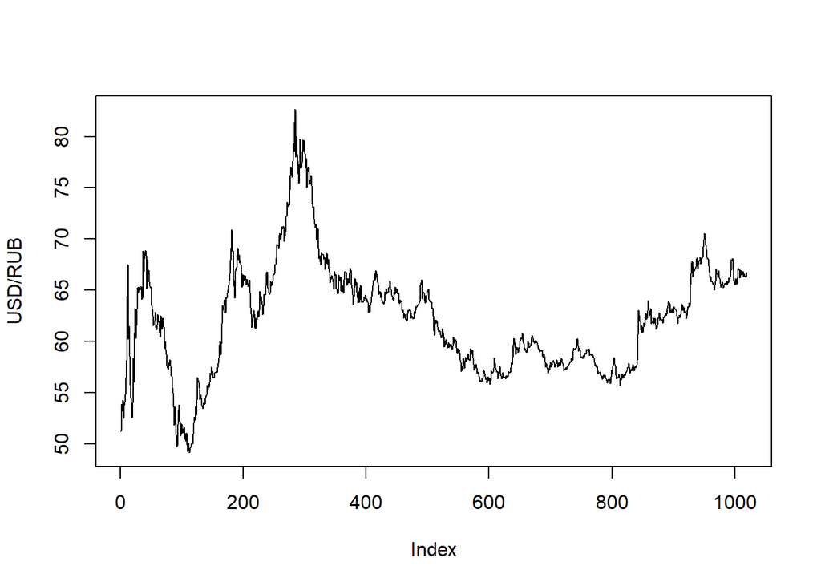

```r
# Replace zero values with previous ones
for (i in 2:nrow(df)) {
  df[i,2] = ifelse(df[i,2] == 0, df[c(i-1),2], df[i,2])
  df[i,3] = ifelse(df[i,3] == 0, df[c(i-1),3], df[i,3])
  df[i,4] = ifelse(df[i,4] == 0, df[c(i-1),4], df[i,4])
  df[i,5] = ifelse(df[i,5] == 0, df[c(i-1),5], df[i,5])
}

plot(df$`USD/RUB`, type = 'l', ylab = 'USD/RUB')
```

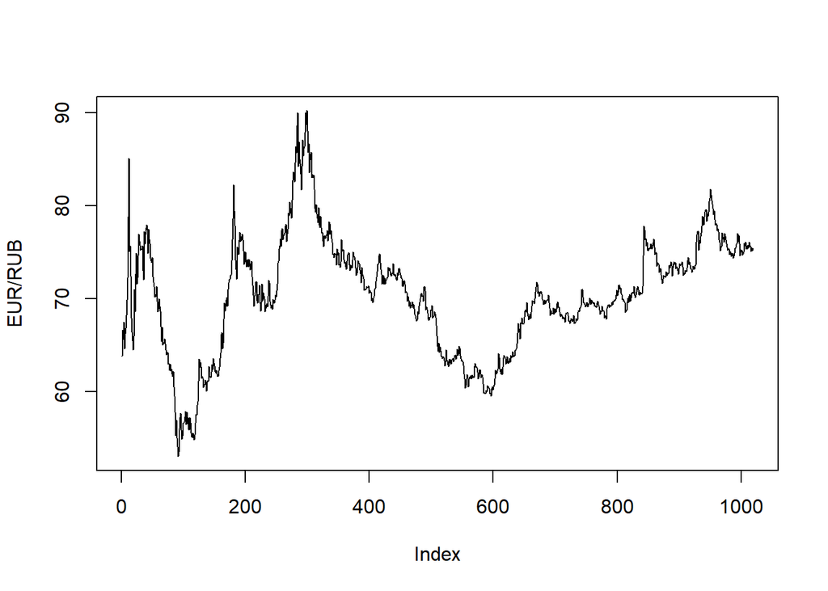

```r
plot(df$`EUR/RUB`, type = 'l', ylab = 'EUR/RUB')
```

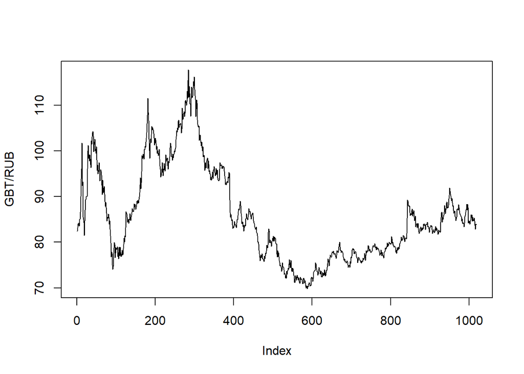

```r
plot(df$`GBT/RUB`, type = 'l', ylab = 'GBT/RUB')
```

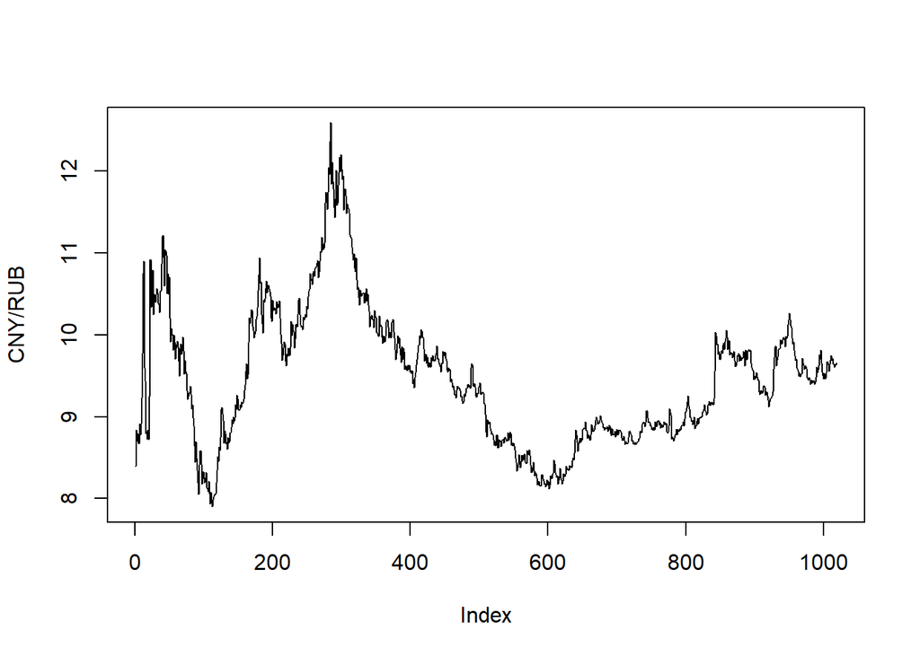

```r
plot(df$`CNY/RUB`, type = 'l', ylab = 'CNY/RUB')
```

## Let’s analyze the data using the principal components method for a portfolio consisting of currency pairs.

### Find the main components for currency pairs.

```r
df_log <- df[,-1] # Remove the year data
pc <- prcomp(df_log, scale. = TRUE) # Finding the main components
```

Average values for currency pairs.

```r
pc$center
```

```
##   USD/RUB   EUR/RUB   GBT/RUB   CNY/RUB
## 62.166076 70.456047 85.851698  9.475153
```

The value of the component for currency pairs.

```r
pc$scale
```

```
##    USD/RUB    EUR/RUB    GBT/RUB    CNY/RUB
##  5.4682256  6.2326750 10.3368021  0.8357793
```

Consider the component.

```r
head(pc$x)
```

```
##            PC1       PC2        PC3         PC4
## [1,] -2.360103 0.7616101 -0.8208123 -0.23761974
## [2,] -1.587165 0.5146090 -0.7371481 -0.02800338
## [3,] -1.772347 0.6694579 -0.7450130 -0.14319422
## [4,] -1.483267 0.4268999 -0.7731946 -0.13145380
## [5,] -1.923023 0.8086847 -0.7417841 -0.12282814
## [6,] -1.716400 0.5406011 -0.7209132 -0.19307476
```

Let’s define the variance values for each component.

```r
v <- summary(pc)$importance
v
```

```
##                             PC1       PC2       PC3       PC4
## Standard deviation     1.878852 0.5798079 0.3236456 0.1702674
## Proportion of Variance 0.882520 0.0840400 0.0261900 0.0072500
## Cumulative Proportion  0.882520 0.9665700 0.9927500 1.0000000
```

### Reflect the percentage of variance explained for each component in the graph.

```r
pc
```

```
## Standard deviations (1, .., p=4):
## [1] 1.8788521 0.5798079 0.3236456 0.1702674
##
## Rotation (n x k) = (4 x 4):
##               PC1        PC2         PC3        PC4
## USD/RUB 0.5055756 -0.3266945  0.75620158 -0.2565603
## EUR/RUB 0.4882334 -0.5888564 -0.62855364 -0.1407008
## GBT/RUB 0.4823411  0.7080442 -0.18051190 -0.4831521
## CNY/RUB 0.5228466  0.2125849  0.02224762  0.8251934
```

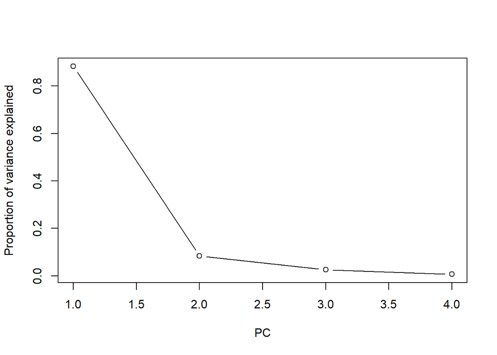

```r
pc_var <- pc$sdev^2
prop_var <- pc_var/sum(pc_var)
plot(prop_var, xlab = "PC", ylab = "Proportion of variance explained", type = "b")
```

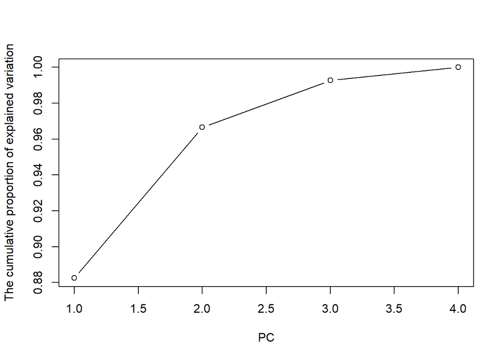

```r
plot(cumsum(prop_var), xlab = "PC",
     ylab = "The cumulative proportion of explained variation",
     type = "b")
```

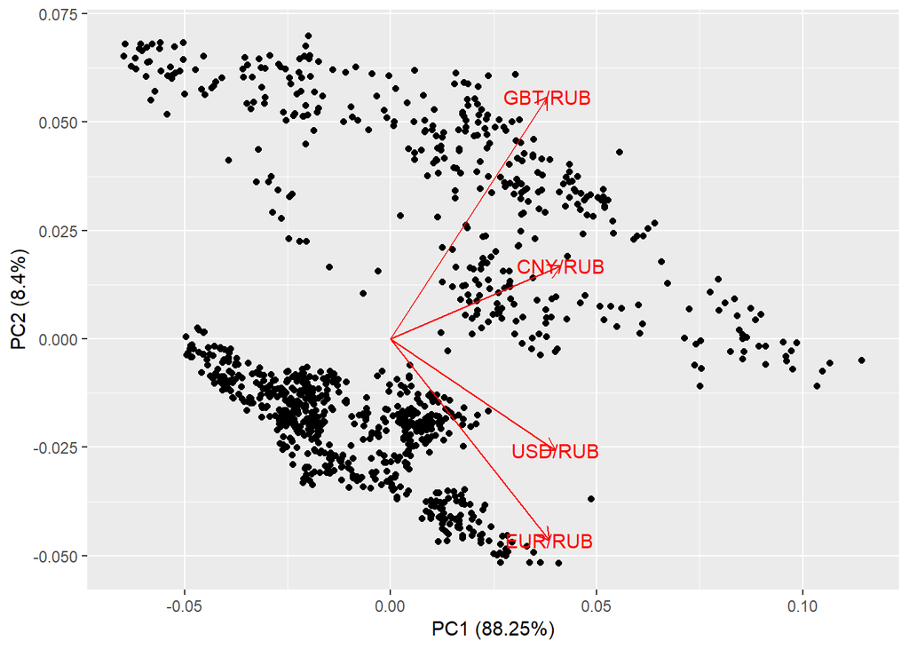

```r
autoplot(pc, loadings = TRUE, loadings.label = TRUE)
```

### Consider the data in the plane of the principal components PC1 and PC2.

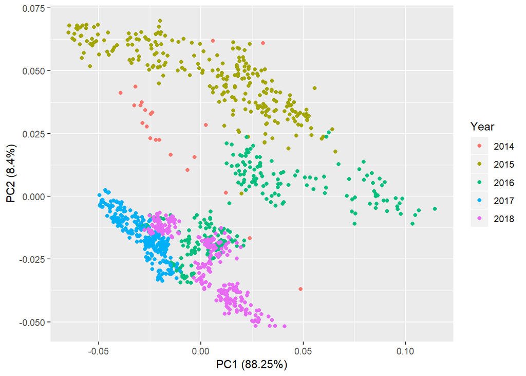

```r
df_log$Year <- as.character(df$Date)
for (i in 1:nrow(df_log)) {
  df_log[i,5] = substr(df_log[i,5], 1, 4)
}
autoplot(pc, data = df_log, colour = 'Year')
```

### Construct a graph for a portfolio of currencies using only 2 principal components: PC1 and PC2.

```r
reconst <- t(t(pc$x[, 1:2] %*% t(pc$rotation[, 1:2]))
             * pc$scale + pc$center)
df_log <- df_log[,-5]
diff <- df_log - reconst
#Stationarity test
adf.test(df_log$`USD/RUB`)
```

```
##
##  Augmented Dickey-Fuller Test
##
## data:  df_log$`USD/RUB`
## Dickey-Fuller = -1.8343, Lag order = 10, p-value = 0.6484
## alternative hypothesis: stationary
```

### Lets display the difference between the actual and the restored values.

### As example lets’s use pair USD/RUB.

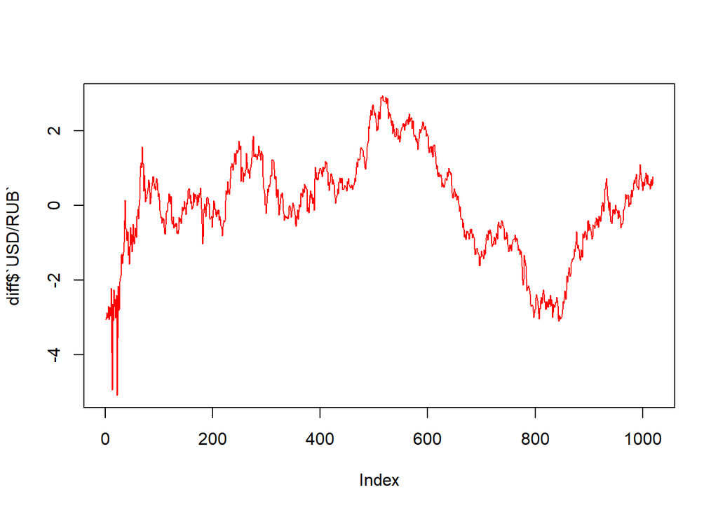

```r
plot(diff$`USD/RUB`, type = 'l', col = 'red')
```

### Let’s imagine simulated data and actual data on the chart on the example of the USD/RUB pair

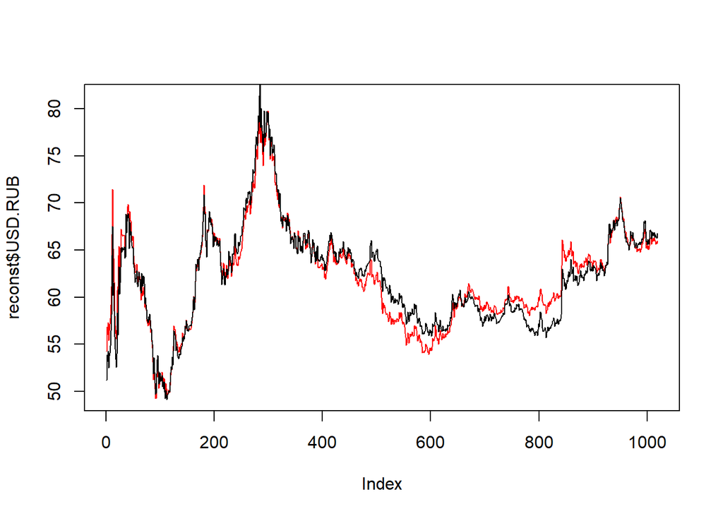

```r
reconst <- data.frame(reconst)
plot(reconst$USD.RUB, type = 'l', col = 'red')
lines(df_log$`USD/RUB`, type = 'l')
```

Analyzing the chart, it can be noted that a lot of time passes from the moment of one intersection to the next, which indicates the inertia of the course. This property will be used when building the strategy below.

## Use principal component method for strategy with basket of currency pairs.

### To develop the strategy, we will use the period to calculate 30 days and the requirement for a share of the explained variance of 90%.

```r
t <- 30  # The estimated window
D <- 0.9 # Required proportion of variance explained

N <- nrow(df) # Number of observations
C <- ncol(df_log) # Number of variables
```

### Let’s create a matrix to fill with data.

```r
strawberry <- matrix(0, nrow = N, ncol = C)
vanilla <- matrix(0, nrow = N, ncol = C)
Npc <- rep(NA, N)
```

### Strategy algorithm.

```r
for (i in (t+1):N) {
  temp <- df_log[(i-t):(i-1), 1:4]
  pc <- prcomp(temp, scale. = TRUE)
  pc_var <- pc$sdev^2
  prop_var <- cumsum(pc_var/sum(pc_var))
  n <- which(prop_var > D)[1]
  if (n != 2) next
  Npc[i] <- n
  reconst <- last(t(t(pc$x[, 1:n] %*% t(pc$rotation[, 1:n])) * pc$scale + pc$center))
  signal <- sign(last(temp) - reconst)
  strawberry[i, 1:4] <- as.numeric(((df_log[i, 1:4] - df_log[i-1, 1:4]) / df_log[i-1, 1:4]) *signal)
  vanilla[i, 1:4] <- as.numeric(((df_log[i, 1:4] - df_log[i-1, 1:4]) / df_log[i-1, 1:4]))
}
```

### Let us compare the result of the strategy using the main components with the naive strategy on the criterion of cumulative profitability.

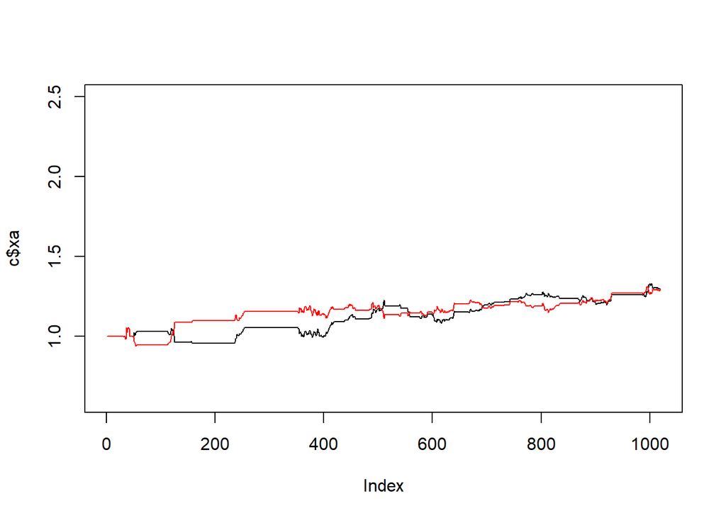

```r
a <- strawberry[,1] # Задаем значение стратегии
b <- vanilla[,1] # Задаем значения пары
c <- data.frame(x = a, y = b) # Создаем отдельный блок даннвх
c$xa <- 1
c$yb <- 1
for(i in 2:nrow(c)) { # Расчитываем прирос
  c[i,3] = c[i-1,3] * (1 + c[i,1])
  c[i,4] = c[i-1,4] * (1 + c[i,2])
}
plot(c$xa, type = 'l', ylim = c(0.6,2.5))
lines(c$yb, col = 'red')
```

The use of the strategy shows the same result as the usual holding of a portfolio consisting of currency pairs.

## Let’s test the strategy using the principal components method for one currency USD / RUB.

```r
df_usd <- data.frame('USD' =  df$`USD/RUB`)
df_usd$USD <- as.numeric(df_usd$USD)
```

### Let’s look at the profitability of the portfolio components consisting of currency pairs.

```r
m_p <- data.frame(strawberry)
mean(m_p$X1) # USD/RUB
```

```
## [1] 0.0002682803
```

```r
mean(m_p$X2) # EUR/RUB
```

```
## [1] -4.45911e-05
```

```r
mean(m_p$X3) # GBP/RUB
```

```
## [1] -0.0002111979
```

```r
mean(m_p$X4) # CNY/RUB
```

```
## [1] -0.0002760248
```

The yield of the USD/RUB pair is the only positive yield in the strategy. Accordingly, it is expected that if you use only the dollar/ruble pair, and the main components of their portfolio of currency pairs.

```r
strawberry_usd <- matrix(0, nrow = N, ncol = C)
vanilla_usd <- matrix(0, nrow = N, ncol = C)
Npc_usd <- rep(NA, N)
```

```r
for (i in (t+1):N) {
  temp <- df_log[(i-t):(i-1), 1:4]
  pc <- prcomp(temp, scale. = TRUE)
  pc_var <- pc$sdev^2
  prop_var <- cumsum(pc_var/sum(pc_var))
  n <- which(prop_var > D)[1]
  Npc_usd[i] <- n
  reconst <- last(t(t(pc$x[, 1:n] %*% t(pc$rotation[, 1:n])) * pc$scale + pc$center))
  signal <- sign(last(temp) - reconst)
  strawberry_usd[i,] <- as.numeric(((df_usd[i,] - df_usd[i-1,]) / df_usd[i-1,]) *signal)
  vanilla_usd[i,] <- as.numeric(((df_usd[i,] - df_usd[i-1,]) / df_usd[i-1,]))
}
```

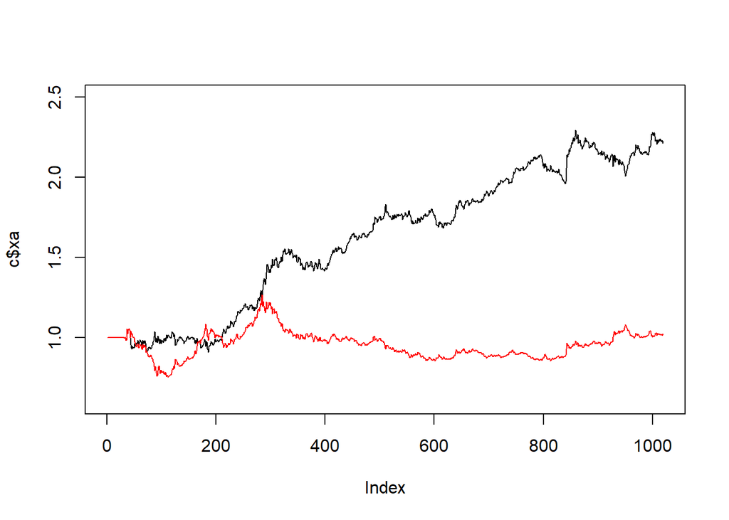

```r
a <- strawberry_usd[,1]
b <- vanilla_usd[,1]
c <- data.frame(x = a, y = b)
c$xa <- 1
c$yb <- 1
for(i in 2:nrow(c)) {
  c[i,3] = c[i-1,3] * (1 + c[i,1])
  c[i,4] = c[i-1,4] * (1 + c[i,2])
}
plot(c$xa, type = 'l', ylim = c(0.6,2.5))
lines(c$yb, col = 'red')
```

## Summary:

### The main components defined in the portfolio consisting of currency pairs are a good method to use in the strategy.